# Linux & Bash

February 15 2017

## The course contents

## The topics of this course

- The file system
- Permissions and processes
- A selection of tools

## The file system

- navigation
- structure
- permissions
- the bin folder
- hidden folders

## The terminal

- executing commands
- man pages (arrgghhh)
- help
- piping
- redirecting

## A selection of tools

- file operations
- file editing
- finding & filtering stuff (grep, find, sed)

## Intro: Why use Linux / Terminal?

## The power of CLI

- CLI = command line interface; typing text instead of using the mouse to give commands
- Modular
- Large number of programs avialable in your toolbox
- Easy to automate
- Easy to combine

## Basic terminology

- The **terminal** is the wrapper program that runs the shell
- The **shell** is the program which actually processes your entered commands
- Shell is actually a specification; **bash** is an implementation of it (and there are others)
- Here, we will regard **console** as a synonym to terminal

## structure of a CL command

- command (program name)
- options (usually in the form of flags like `-i`, `--verbose`)
- other arguments

## Single versus double quotes

- double quotes are expanded by shell
- single quotes passed literally

```bash
echo "USER is $USER"
echo 'USER is $USER'
```

```
  USER is michiel
  USER is $USER
```

- use quotes when passing arguments with spaces

## Part 1.1: The file system

## The Linux file system (1)

- Linux organizes files in a tree-like pattern
- Each directory can contain other files and directories
- The first directory is called the *root* directory: `/..`
- Linux has a single-filesystem tree, *regardless how many storage devices are attached* (mounted)
- The system contains many directories for “administration” purpose: /bin /boot /dev /lib /etc
- Each user has a home environment

## The Linux file system (2)

Important root folders

- `/bin` – essential system executables (single user system)
- `/sbin` – superuser executables (single user system)
- `/usr/bin` – idem (multi user system)
- `/usr/sbin` – idem (multi user system)
- `/usr/local/bin` – local executables (usually simlinks)
- `/usr/local/sbin` – idem - for superuser

## The working directory

In any terminal session, you will have a *working directory*. You get its current location by typing `pwd` (**p**rint **w**orking **d**irectory)

```bash
pwd
```

```
## /Users/michiel/OneDrive - Hanzehogeschool Groningen/courses/BFV_1_Thema04_Inf4_R_Linux
```

## changing the working directory: `cd`

`cd` (**c**hange **d**irectory) can be used in several ways:

- `cd <absolute path>` *e.g.* `cd /homes/michiel/tmp/`
- `cd <relative path>`*e.g.* `cd ../tmp/foo`, `/data`
- `cd ..` to go up one level
- `cd -` to toggle between two directories

## listing the contents: `ls`

- `ls` lists the contents of a folder
- if none is provided, defaults to current working directory.
- `ls` knows *many* options (type `man ls` to find out), but these are most relevant
  - `ls -a` also show hidden files (starting with a dot)
  - `ls -l` use long format (including date, size, rights)
  - `ls -R` list directory contents recursively
- use `ls -l <filename>` to get info on a single file

## Combining flags

With `ls`, as with many CL tools, you can combine (short) flags into one string

This command

`ls -l -a -h -G`

is the same as

`ls -lahG`

## The `ls -l` long format

The long format has this structure

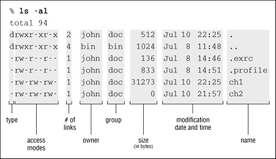

## `cd` and `ls` demo

Given this structure:

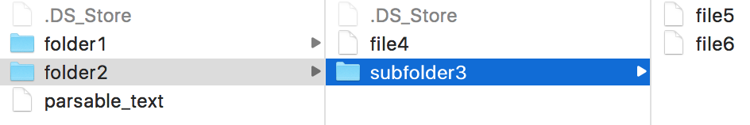

Folder Structure

Let’s have a look at some navigation possibilities.

```bash
cd data/
ls
cd folder1
pwd
cd ../folder2 #same as two commands: cd .. and cd folder2
pwd
ls
```

```
## chsi_sample_measuresofhealth.csv
## data.zip
## error.log
## folder1
## folder2
## hello.log
## normal.log
## some_text
## streams_demo.py
## /Users/michiel/OneDrive - Hanzehogeschool Groningen/courses/BFV_1_Thema04_Inf4_R_Linux/data/folder1
## /Users/michiel/OneDrive - Hanzehogeschool Groningen/courses/BFV_1_Thema04_Inf4_R_Linux/data/folder2
## file4
## subfolder3
```

## Part 1.2: The file system: Working with Files

## Inspection file contents

There are a few programs that support this, each with its own specifics

## Use `less` to read and scan text

- `less` is used to browse and search text files
- it allows scrolling up and down using arrow keys or mouse
- it also supports keyword search: type `/keyword_to_search` and hit `ENTER` to do this
- `more` is its handicapped predecessor

## Fetch a `head`-ing

- Use `head` to fetch the first few lines of one or more files
- Defaults to 10 lines
- Supports multiple files
- Fetching the first 3 lines from file `some_text` (contents copied from Wikipedia):

```bash
head -3 ./data/some_text
```

```
  Linux is a Unix-like and mostly POSIX-compliant[12] computer
  operating system (OS) assembled under the model of free and
  open-source software development and distribution.
```

## Fetch a file `tail`

- Same as `head`, but applied to the end of files

```bash
tail -4 ./data/some_text
```

```
  facility automation controls, televisions,[26][27] video game
  consoles and smartwatches.[28]
  ...
  source: Wikipedia
```

Note: you may have noticed this file has no extension; Linux does not really care about that. Use the command `file <filename>` to find out if unsure.

## Use `cat` to echo the contents

- This is often used in pipe and redicrect operations, discussed later
- Can be applied to multiple files
- Often used to combine contents:

```bash
cat file1.txt > all.txt
cat file2.txt >> all.txt
```